# DAVID_BLANCO_Assignment3

David Blanco 000858381

2023-04-06

# About Dataset

The original data was taken from: https://www.kaggle.com/datasets/salvatorerastelli/spotify-and-youtube

The dataset shows the statistics for the Top 10 songs of various spotify artists and their yt video

# Import the data

Read the file Spotify_Youtube.csv, save it in a tibble, and select the relevant data.

```r
df<- read.csv("Spotify_Youtube.csv", header = TRUE)
names(df)
```

```
##  [1] "X"                "Artist"           "Url_spotify"      "Track"
##  [5] "Album"            "Album_type"       "Uri"              "Danceability"
##  [9] "Energy"           "Key"              "Loudness"         "Speechiness"
## [13] "Acousticness"     "Instrumentalness" "Liveness"         "Valence"
## [17] "Tempo"            "Duration_ms"      "Url_youtube"      "Title"
## [21] "Channel"          "Views"            "Likes"            "Comments"
## [25] "Description"      "Licensed"         "official_video"   "Stream"
```

```r
tb <- select(df,"X", "Artist", "Track","Album", "Album_type", "Danceability", "Energy", "Key", "Loudness", "Speechiness", "Acousticness", "Instrumentalness", "Liveness", "Valence", "Tempo", "Duration_ms", "Title", "Channel", "Views", "Likes", "Comments", "official_video", "Stream") %>% as_tibble()
```

## Data Cleaning

Eliminate null values (na)

```r
tb <- na.omit(tb)
```

Eliminate the track that are duplicated but are performance by different artists.

```r
tb <- tb %>%
  distinct(Track,.keep_all = TRUE)
```

## Add total_plays field

The new field will be calculated adding the number of views in youtube and the number of streams in spotify. This new field will be called total_plays.

```r
tb <- tb %>%
  mutate(total_plays = Views + Stream)
```

# Descriptive analysis

After select the quantitative variables with the function summary we obtain the descriptive analysis of these variables.

```r
quant_var <- select(tb, "Danceability","Energy", "Key", "Loudness", "Speechiness", "Acousticness", "Instrumentalness", "Liveness", "Valence", "Tempo", "Duration_ms","Views", "Likes", "Comments", "Stream", "total_plays" )
summary(quant_var)
```

```
##   Danceability       Energy               Key           Loudness
##  Min.   :0.000   Min.   :0.0000203   Min.   : 0.00   Min.   :-46.251
##  1st Qu.:0.515   1st Qu.:0.5050000   1st Qu.: 2.00   1st Qu.: -8.875
##  Median :0.636   Median :0.6660000   Median : 5.00   Median : -6.551
##  Mean   :0.619   Mean   :0.6353498   Mean   : 5.28   Mean   : -7.678
##  3rd Qu.:0.741   3rd Qu.:0.8000000   3rd Qu.: 8.00   3rd Qu.: -4.946
##  Max.   :0.975   Max.   :1.0000000   Max.   :11.00   Max.   :  0.920
##   Speechiness       Acousticness       Instrumentalness       Liveness
##  Min.   :0.00000   Min.   :0.0000011   Min.   :0.0000000   Min.   :0.0145
##  1st Qu.:0.03540   1st Qu.:0.0415000   1st Qu.:0.0000000   1st Qu.:0.0940
##  Median :0.05020   Median :0.1860000   Median :0.0000028   Median :0.1240
##  Mean   :0.09488   Mean   :0.2878541   Mean   :0.0565870   Mean   :0.1917
##  3rd Qu.:0.10300   3rd Qu.:0.4720000   3rd Qu.:0.0005170   3rd Qu.:0.2360
##  Max.   :0.96400   Max.   :0.9960000   Max.   :1.0000000   Max.   :1.0000
##     Valence           Tempo         Duration_ms          Views
##  Min.   :0.0000   Min.   :  0.00   Min.   :  30985   Min.   :2.600e+01
##  1st Qu.:0.3390   1st Qu.: 96.96   1st Qu.: 180824   1st Qu.:1.819e+06
##  Median :0.5380   Median :119.97   Median : 213477   Median :1.382e+07
##  Mean   :0.5305   Mean   :120.68   Mean   : 222688   Mean   :8.777e+07
##  3rd Qu.:0.7290   3rd Qu.:139.98   3rd Qu.: 252225   3rd Qu.:6.651e+07
##  Max.   :0.9930   Max.   :243.37   Max.   :4676058   Max.   :8.080e+09
##      Likes             Comments           Stream           total_plays
##  Min.   :       0   Min.   :      0   Min.   :6.574e+03   Min.   :7.020e+03
##  1st Qu.:   21345   1st Qu.:    510   1st Qu.:1.696e+07   1st Qu.:2.505e+07
##  Median :  117316   Median :   3137   Median :4.813e+07   Median :7.591e+07
##  Mean   :  610279   Mean   :  25439   Mean   :1.300e+08   Mean   :2.178e+08
##  3rd Qu.:  480773   3rd Qu.:  13512   3rd Qu.:1.329e+08   3rd Qu.:2.141e+08
##  Max.   :50788626   Max.   :9131761   Max.   :3.387e+09   Max.   :9.586e+09
```

## Correlation Matrix

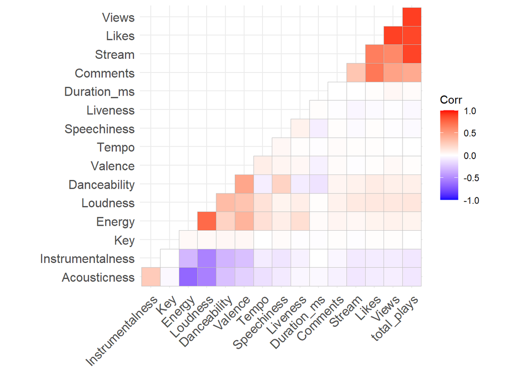

```r
corr_mat <- cor(quant_var)
ggcorrplot(corr_mat, hc.order = TRUE,
    type = "lower")
```

The correlation matrix show a high correlation in the data is between the views in youtube with likes and comments. We can say that the high number of views cause a high number of likes and comments, but to be sure about this statement it would be necessary to develop a deeper tests that wont be show in this analysis.

# Histograms of quantitative variables

Next with the use of purrr library and ggplot2 all the quantitative variables will show his respective histogram to be analyzed.

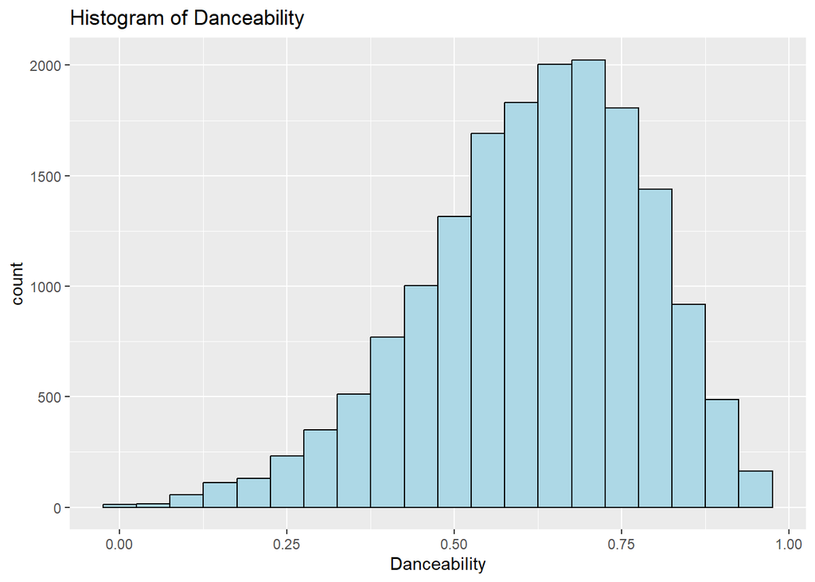

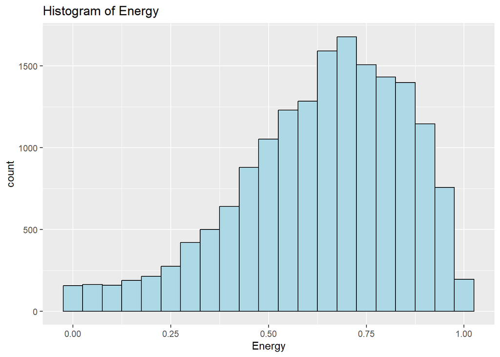

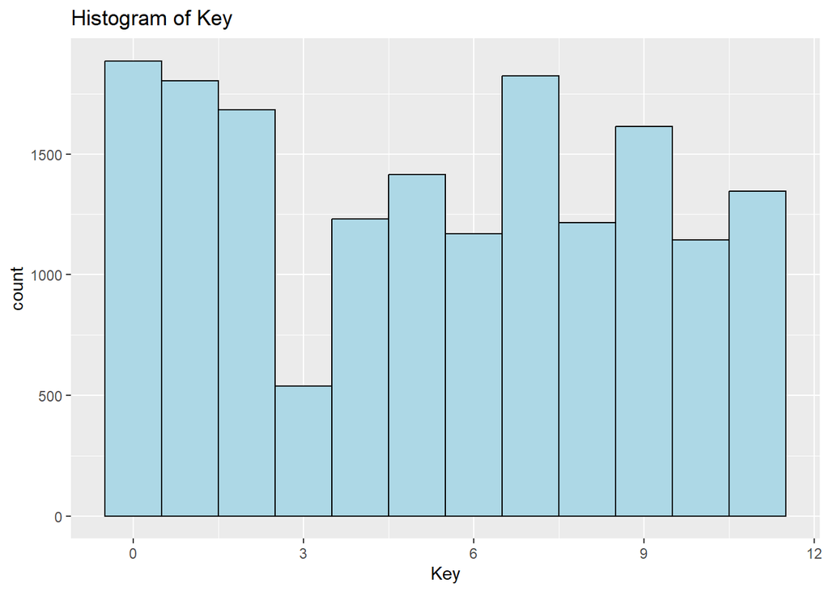

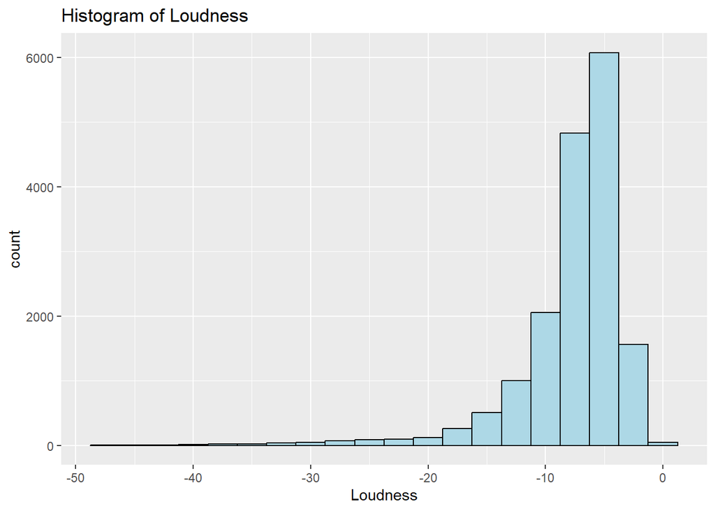

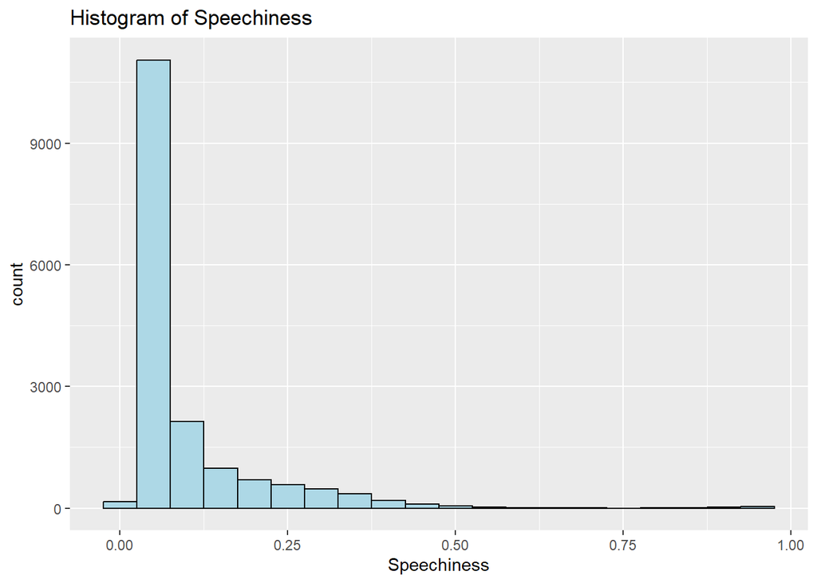

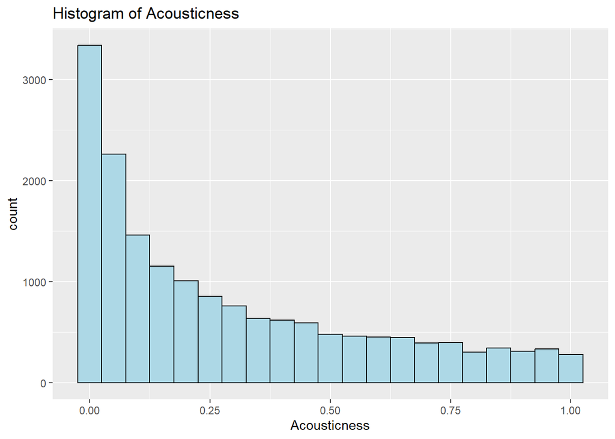

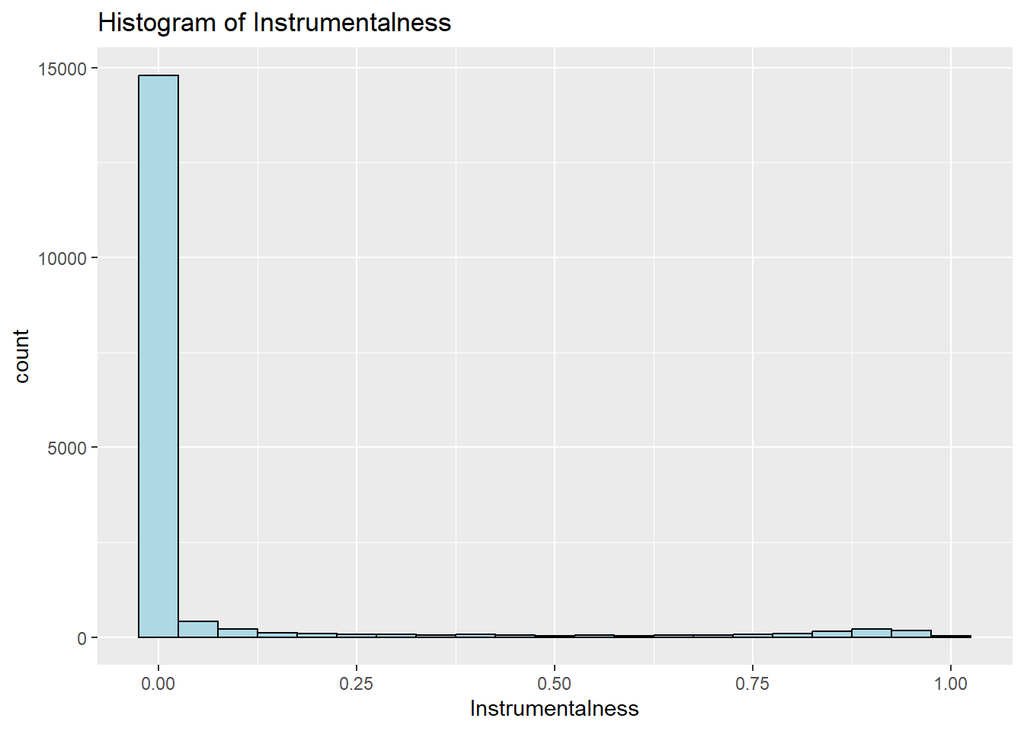

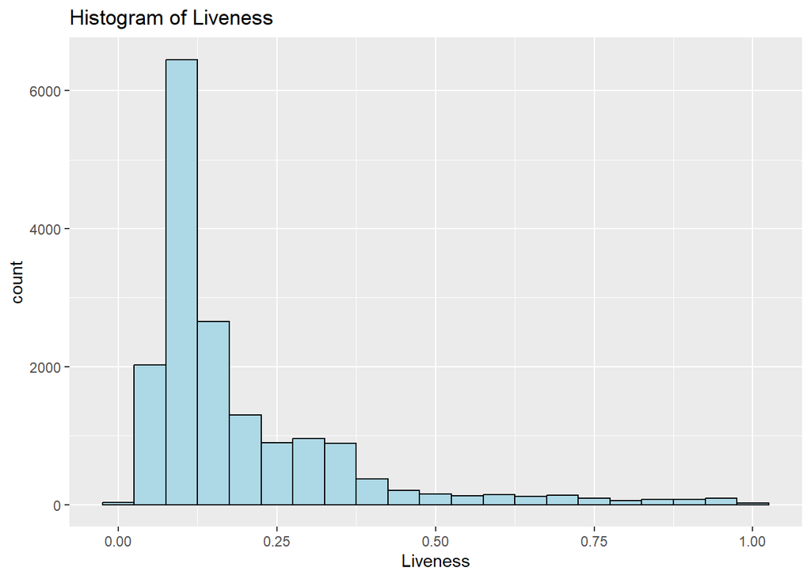

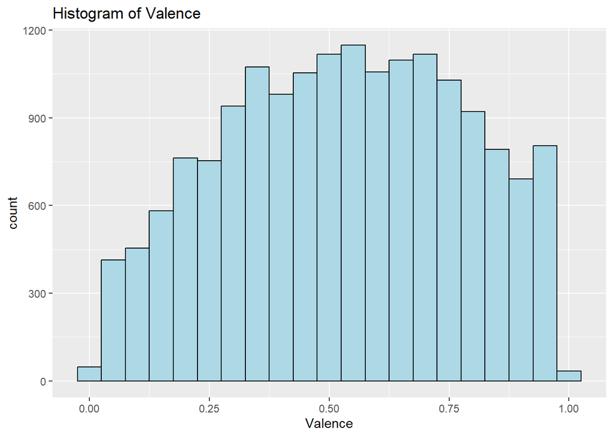

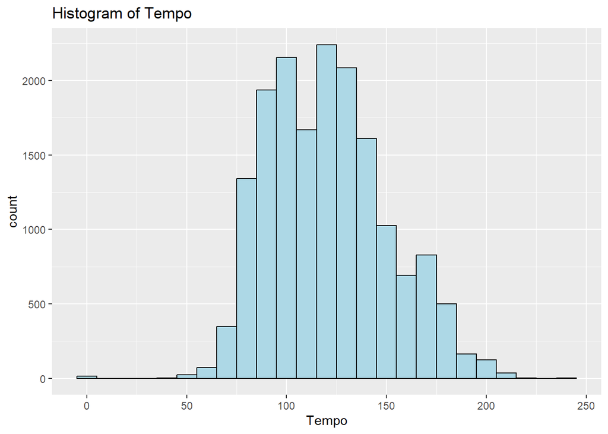

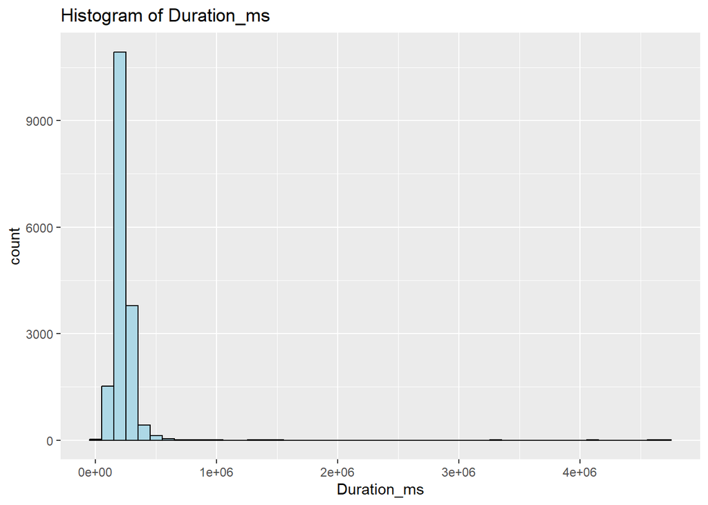

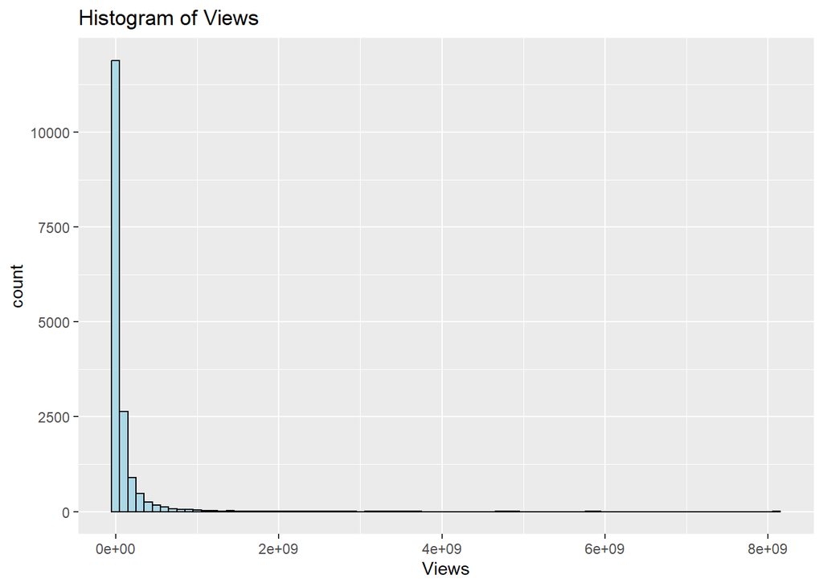

[4 more figures not shown]

```r
to_plot_hist <- c( "Danceability","Energy", "Key", "Loudness", "Speechiness", "Acousticness", "Instrumentalness", "Liveness", "Valence", "Tempo", "Duration_ms","Views", "Likes", "Comments", "Stream", "total_plays" )

# Define the bin size of each of the histograms
binwidths <- c(Danceability = 0.05, Energy = 0.05, Key = 1, Loudness = 2.5,
               Speechiness = 0.05, Acousticness = 0.05, Instrumentalness = 0.05,
               Liveness = 0.05, Valence = 0.05, Tempo = 10, Duration_ms = 100000,
               Views =100000000, Likes = 1000000, Comments = 100000,
               Stream = 100000000, total_plays = 100000000)


# Define a function that takes a variable name and generates the corresponding histogram
generate_histogram <- function(var,binwidth) {
  ggplot(tb, aes(x = !!sym(var))) +
    geom_histogram(binwidth = binwidth, color = "black", fill = "lightblue") +
    labs(title = paste0("Histogram of ", var))
}

# Use purrr's map() function to apply the generate_histogram function to each variable in quant_var
histograms <- map2(to_plot_hist,binwidths, generate_histogram)

# Print the histograms
histograms
```

# Top ten artist by Views, Stream and Total plays

To analyze the outliers showed in the histograms, the top ten artists will be show in horizontal bar graphs. The factors to see how sucessful is a song are: Total views in youtube, total streams in spotify, and the total of plays of each song (views + streams)

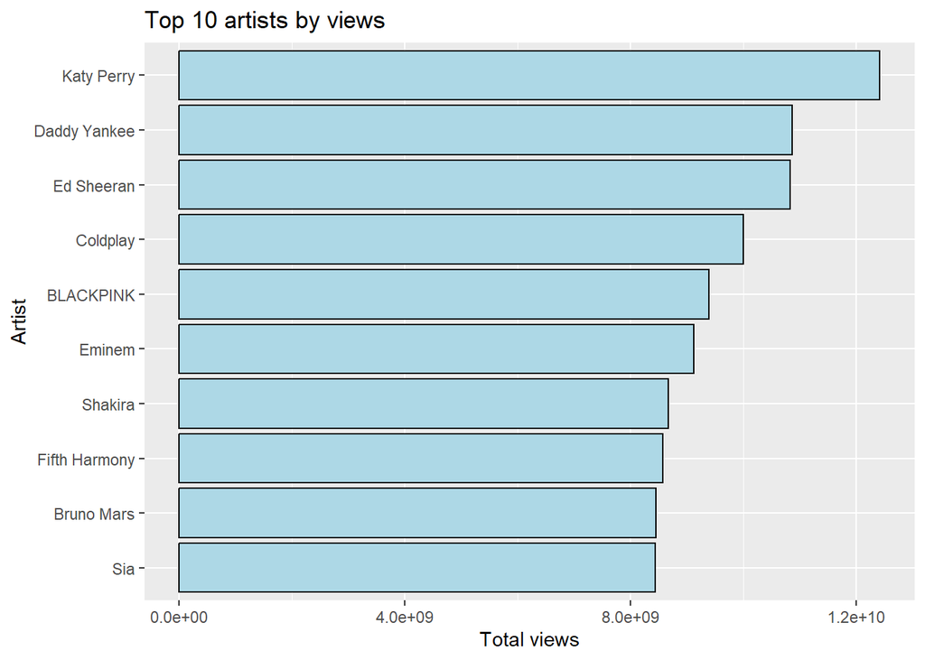

```r
# create a tibble with the top 10 artists by views
top_artists_views <- tb %>%
  group_by(Artist) %>%
  summarise(total_views = sum(Views)) %>%
  ungroup() %>%
  arrange(desc(total_views)) %>%
  slice(1:10)

# create a horizontal bar chart of the top 10 artists by views
ggplot(top_artists_views, aes(x = total_views, y = reorder(Artist, total_views))) +
  geom_col(color = "black", fill = "lightblue") +
  labs(title = "Top 10 artists by views", x = "Total views", y = "Artist") +
  theme(legend.position = "none")
```

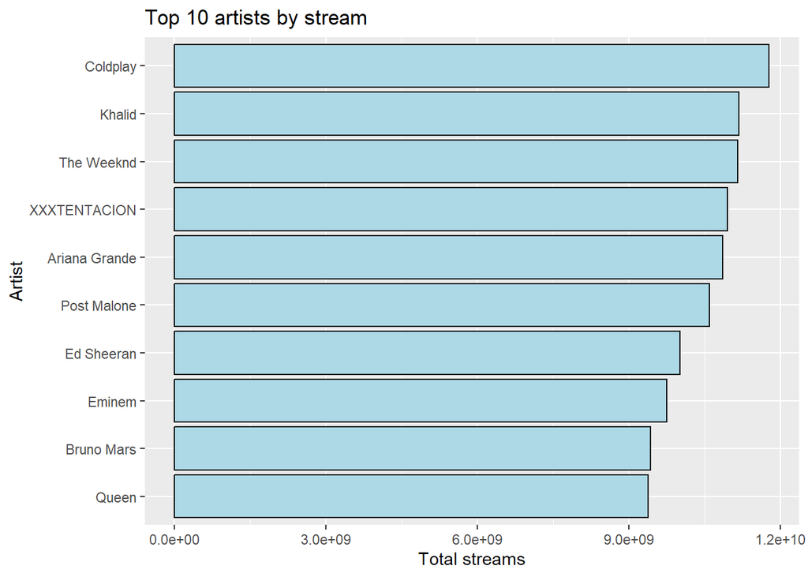

```r
# create a tibble with the top 10 artists by stream
top_artists_stream <- tb %>%
  group_by(Artist) %>%
  summarise(total_streams = sum(Stream)) %>%
  ungroup() %>%
  arrange(desc(total_streams)) %>%
  slice(1:10)

# create a horizontal bar chart of the top 10 artists by stream
ggplot(top_artists_stream, aes(x = total_streams, y = reorder(Artist, total_streams))) +
  geom_col(color = "black", fill = "lightblue") +
  labs(title = "Top 10 artists by stream", x = "Total streams", y = "Artist") +
  theme(legend.position = "none")
```

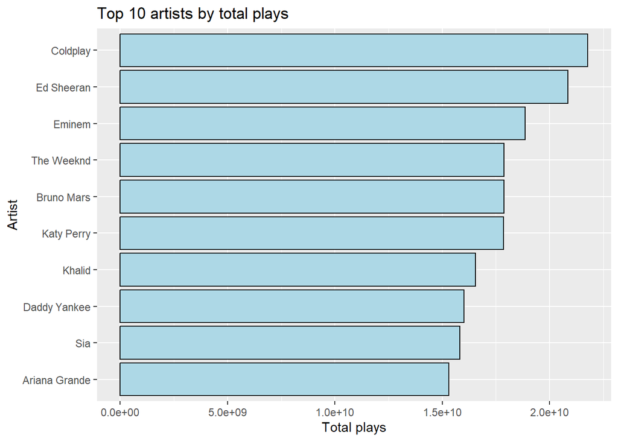

```r
# create a tibble with the top 10 artists by total_plays
top_artists_total_plays <- tb %>%
  group_by(Artist) %>%
  summarise(total_plays = sum(Views) + sum(Stream)) %>%
  ungroup() %>%
  arrange(desc(total_plays)) %>%
  slice(1:10)

# create a horizontal bar chart of the top 10 artists by total_plays
ggplot(top_artists_total_plays, aes(x = total_plays, y = reorder(Artist, total_plays))) +
  geom_col(color = "black", fill = "lightblue") +
  labs(title = "Top 10 artists by total plays", x = "Total plays", y = "Artist") +
  theme(legend.position = "none")
```

The graphs shows different artists according what variable we compare. In case of the views Katy Perry is the artist number one and Colplay is the artist number one by stream and by total plays.

# Top ten songs by Views, Stream and Total plays

```r
# create a tibble with the top 10 songs by views
top_songs_views <- tb %>%
  group_by(Track, Artist) %>%
  summarise(total_views = sum(Views)) %>%
  ungroup() %>%
  arrange(desc(total_views)) %>%
  slice(1:10)
```

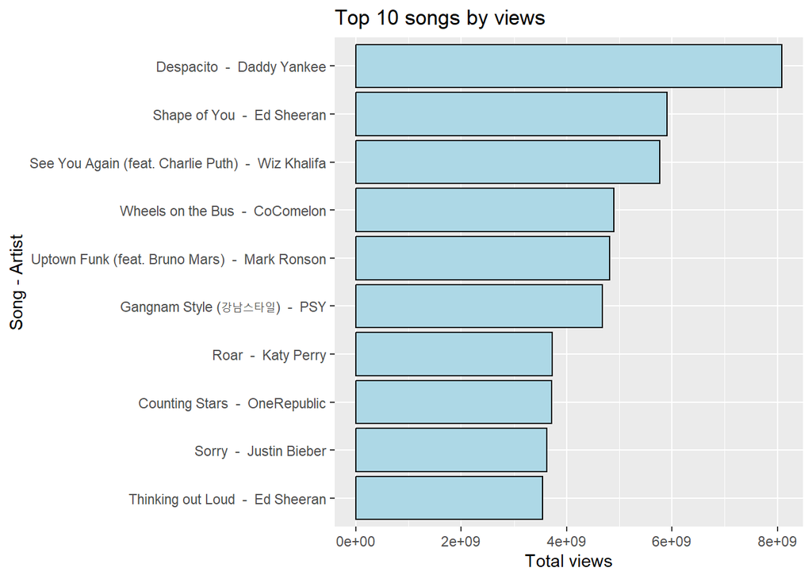

```r
# create a horizontal bar chart of the top 10 songs by views
ggplot(top_songs_views, aes(x = total_views, y = reorder(paste(Track, " - ", Artist), total_views))) +
  geom_col(color = "black", fill = "lightblue") +
  labs(title = "Top 10 songs by views", x = "Total views", y = "Song - Artist") +
  theme(legend.position = "none")
```

```r
# create a tibble with the top 10 songs by stream
top_songs_stream <- tb %>%
  group_by(Track, Artist) %>%
  summarise(total_streams = sum(Stream)) %>%
  ungroup() %>%
  arrange(desc(total_streams)) %>%
  slice(1:10)
```

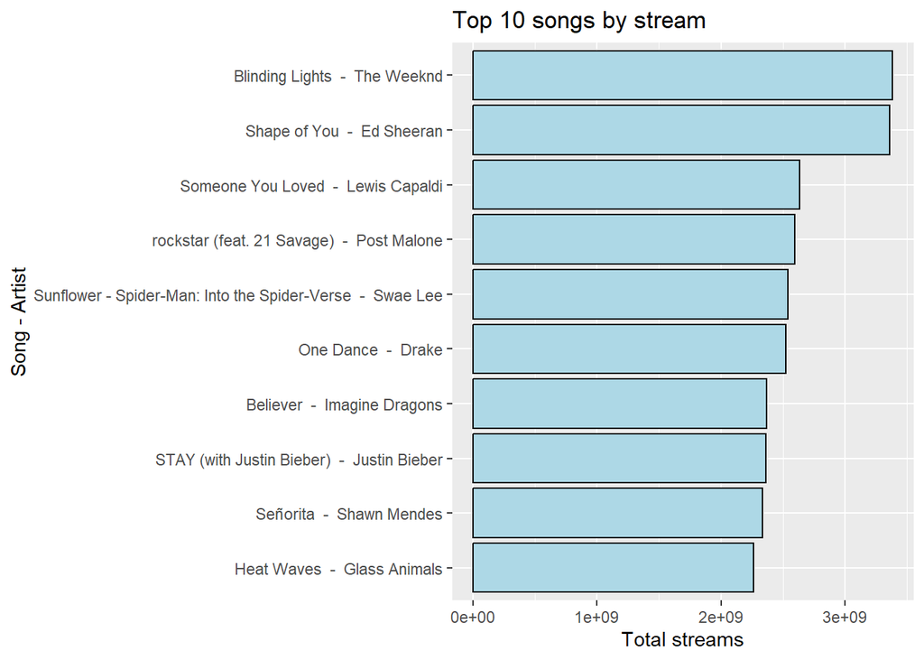

```r
# create a horizontal bar chart of the top 10 songs by stream
ggplot(top_songs_stream, aes(x = total_streams, y = reorder(paste(Track, " - ", Artist), total_streams))) +
  geom_col(color = "black", fill = "lightblue") +
  labs(title = "Top 10 songs by stream", x = "Total streams", y = "Song - Artist") +
  theme(legend.position = "none")
```

```r
# create a tibble with the top 10 songs by total_plays
top_songs_total_plays <- tb %>%
  group_by(Track, Artist) %>%
  summarise(total_plays = sum(Views) + sum(Stream)) %>%
  ungroup() %>%
  arrange(desc(total_plays)) %>%
  slice(1:10)
```

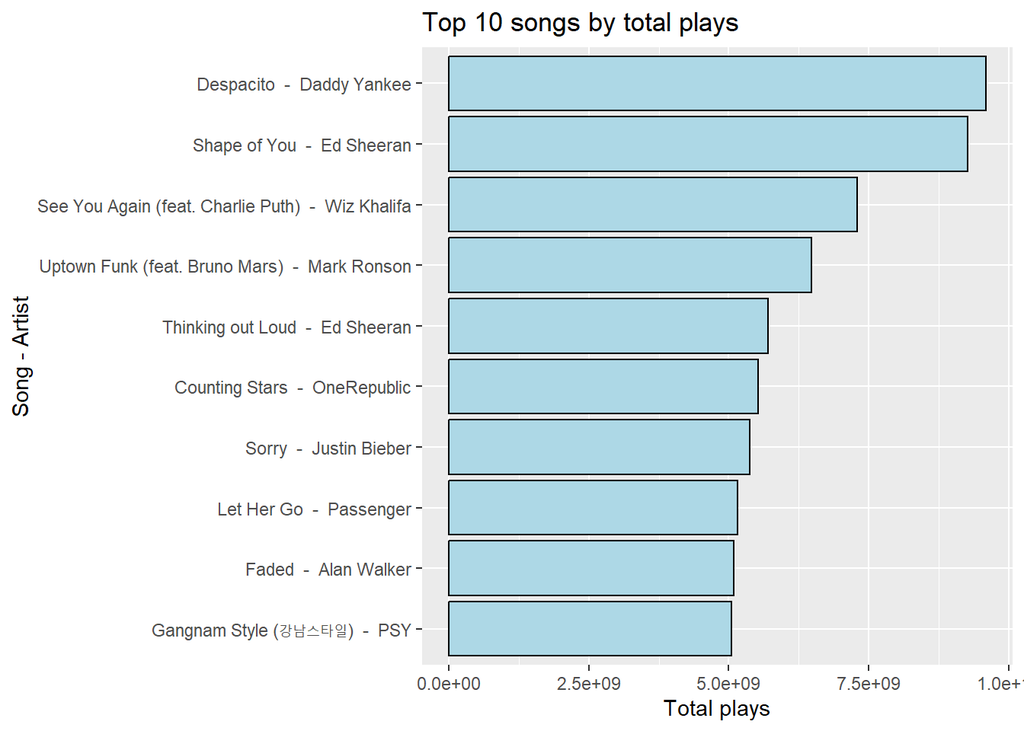

```r
# create a horizontal bar chart of the top 10 songs by total_plays
ggplot(top_songs_total_plays, aes(x = total_plays, y = reorder(paste(Track, " - ", Artist), total_plays))) +
  geom_col(color = "black", fill = "lightblue") +
  labs(title = "Top 10 songs by total plays", x = "Total plays", y = "Song - Artist") +
  theme(legend.position = "none")
```

According the graphs the top one songs are Despacito, Blinding Lights and Despacito by number of views, number of streams and by total plays respectively.

# Conclusions and next steps

- The success of an artist or a song can vary according the method that we choose to compare how is their performance.
- Artists can be classified into three groups based on their success. The first group includes those who have all of their songs in the top ten, like Daddy Yankee, as well as a single hit. The second group includes artists who have multiple successful songs that allow them to be part of the top ten, such as Coldplay. The third group includes artists who have one hit wonder that gives them a position in the top ten most played songs, like PSY with “Gangnam Style”.
- To conduct a deeper analysis, it is recommended to implement predictive models that can classify songs based on their characteristics and attempt to predict whether a song will be successful or not on different platforms.